# Principal Component Analysis

**Course:** HUDK 4050, Week 8

**Author:** Zhichun Liu

**Assignment:** ICE6

**Objectives:** At the end of this ICE, you will be able to:

1. develop intuitions about principal component analysis
2. implement the PCA algorithm for dimension reduction purposes

## Principal Component Analysis

In this ICE, we explore start to explore principal component analysis (PCA). It is fundamentally a dimensionality reduction algorithm, and it can also be useful as a tool for visualization, noise filtering, feature section, many more. After a brief conceptual discussion of the PCA algorithm, we will see a couple examples of these further applications.

Let’s first start with a simple 2 dimension example with 200 random points that are roughly around $y = 1 + 2x$.

```r
library(tidyverse)
```

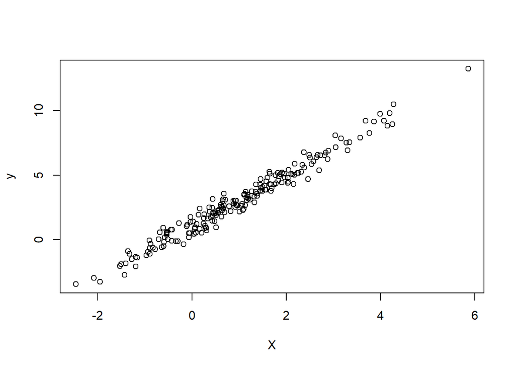

```r
set.seed(123)

# A list of 200 values of x with means of 1 and sd of 1.5
X <- rnorm(200, mean = 1, sd = 1.5)
# A list of 200 residuals with sd of 0.5
res <- rnorm(200, mean = 0, sd = 0.5)
y <- 1 + 2 * X + res

twoDData <- tibble(X = X, y = y)
plot(twoDData)
```

The relationship can be well-explained by our simple linear regression, but the problem we are looking here is slightly different: Rather than using an supervised approach to *teach* an algorithm to predict y values from x values, we want to use an unsupervised learning algorithm to *learn* about the relationship between xs and ys by finding a list of the principal axes in the data, and using those axes to describe the dataset.

Using `prccomp()` function, we can compute this as follows:

```r
pca <- prcomp(twoDData, scale. = TRUE)
# scale. = TRUE is a logical value indicating whether the variables should be scaled to have unit variance before the analysis takes place. The default is FALSE for consistency with the dataset, but in general scaling is advisable.
```

A summary of our pca will give us the proportion of variance accounted for by each component. If you only want to check the standard deviation explained by each component, you can call `pca$sdev`.

```r
summary(pca)
```

```
## Importance of components:
##                           PC1     PC2
## Standard deviation     1.4088 0.12357
## Proportion of Variance 0.9924 0.00763
## Cumulative Proportion  0.9924 1.00000
```

The rotation of the axies are listed in:

```r
pca$rotation
```

```
##         PC1        PC2
## X 0.7071068  0.7071068
## y 0.7071068 -0.7071068
```

With the pca vector information, we can use it to transform the original data. This transformation from data axes to principal axes is an affine transformation, which basically means it is composed of a translation, rotation, and uniform scaling.

While this algorithm to find principal components may seem like just a mathematical curiosity, it turns out to have very far-reaching applications in the world of machine learning and data exploration.

For example, it can be used for dimension reduction if the number of principal component is smaller than the original data dimensions.

## PCA for Dimension Reducation

In this example, we are going to keep only the PC1 because it preserves more information. In another word, discarding PC2 is not going to cause too much information lost.

First, let’s select only the first PC1 and the rotation vector for PC1.

```r
pc1 <- pca$x[,1]
rotation1 <- pca$rotation[,1]
```

Then the reconstruction is simplily a multiplication between two matrices. You will need a matrix multiplication operator `%*%` and transpose function `t()`

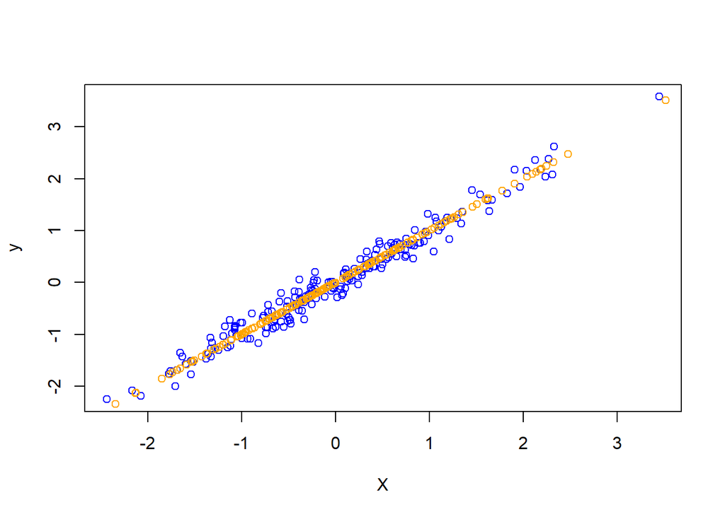

```r
plot(scale(twoDData), col = "blue") # the original data is scaled because PCA is also scaled
points(pc1 %*% t(rotation1), col = "orange")
```

The blue points are the original data, while the organge points are the projected version. This makes clear what a PCA dimensionality reduction means: the information along the least important principal axis or axes is removed, leaving only the component(s) of the data with the highest variance. The fraction of variance that is cut out (proportional to the spread of points about the line formed in this figure) is roughly a measure of how much “information” is discarded in this reduction of dimensionality.

This reduced-dimension dataset is in some senses “good enough” to encode the most important relationships between the points: despite reducing the dimension of the data by 50%, the overall relationship between the data points are mostly preserved.

## PCA Example in an Intelligent Tutoring System

Next, let’s see a real world example: We will be using data from the Assistments Intelligent Tutoring system. This system gives students hints based on how they perform on math problems. We want to see if we can build a decision tree to help teachers decide which students to follow up with, based on students’ performance in Assistments.

Here are the variables:

- `id` - student id
- `prior_prob_count` - The number of problems a student has done in the system prior to the current session
- `prior_percent_correct` - The percentage of problems a student has answered correctly piror to the current session
- `problems_attempted` - The number of problems a student has attempted in this current session
- `mean_correct` - The percentage of correct problems in this currect session
- `mean_hint` - The average number of hints the student requested in the current session
- `mean_attempt` - The average attempts for each problem
- `mean_confidence` - The reported confidence a student has reported at the end of the session

```r
ICEdata <- read_csv("ICE6_Data.csv")
ICEdata
```

| id | prior_prob_count | prior_percent_correct | problems_attempted | mean_correct | mean_hint | mean_attempt | mean_confidence |
| --- | --- | --- | --- | --- | --- | --- | --- |
| 172777 | 650 | 0.7230769 | 4 | 1.0000000 | 0.00000000 | 1.0000000 | 0.5501593 |
| 175658 | 1159 | 0.8006903 | 22 | 0.4545455 | 2.22727273 | 1.2272727 | 0.4375148 |
| 175669 | 1239 | 0.6569814 | 11 | 0.6363636 | 1.36363636 | 1.7272727 | 0.5110604 |
| 176151 | 1246 | 0.7295345 | 16 | 0.7500000 | 0.56250000 | 1.1875000 | 0.4915777 |
| 176165 | 1299 | 0.5681293 | 6 | 0.3333333 | 2.16666667 | 2.0000000 | 0.4098869 |
| 176168 | 1415 | 0.6848057 | 11 | 0.5454545 | 2.00000000 | 1.2727273 | 0.6015113 |
| 176461 | 753 | 0.4993360 | 11 | 0.3636364 | 2.09090909 | 2.0000000 | 0.4426135 |
| 176486 | 772 | 0.5764249 | 10 | 0.3000000 | 3.40000000 | 2.9000000 | 0.5039963 |
| 176488 | 529 | 0.6748582 | 19 | 0.4210526 | 2.31578947 | 1.7368421 | 0.5175256 |
| 176494 | 1226 | 0.6443719 | 12 | 0.2500000 | 2.91666667 | 1.6666667 | 0.5877119 |

[output cut: 332 more lines]

```r
ICEdata_noid <- ICEdata %>% select(-id)
icepca <- prcomp(ICEdata_noid, scale. = FALSE) # Here let's see a unscaled example
summary(icepca)
```

```
## Importance of components:
##                            PC1     PC2     PC3    PC4    PC5    PC6    PC7
## Standard deviation     319.233 9.82811 0.89846 0.6489 0.2033 0.1269 0.1044
## Proportion of Variance   0.999 0.00095 0.00001 0.0000 0.0000 0.0000 0.0000
## Cumulative Proportion    0.999 0.99999 1.00000 1.0000 1.0000 1.0000 1.0000
```

From the explained variances, we can see that there are at two components explaining substantially more variances than other components. So let’s reduce the the data to two dimensions and plot it.

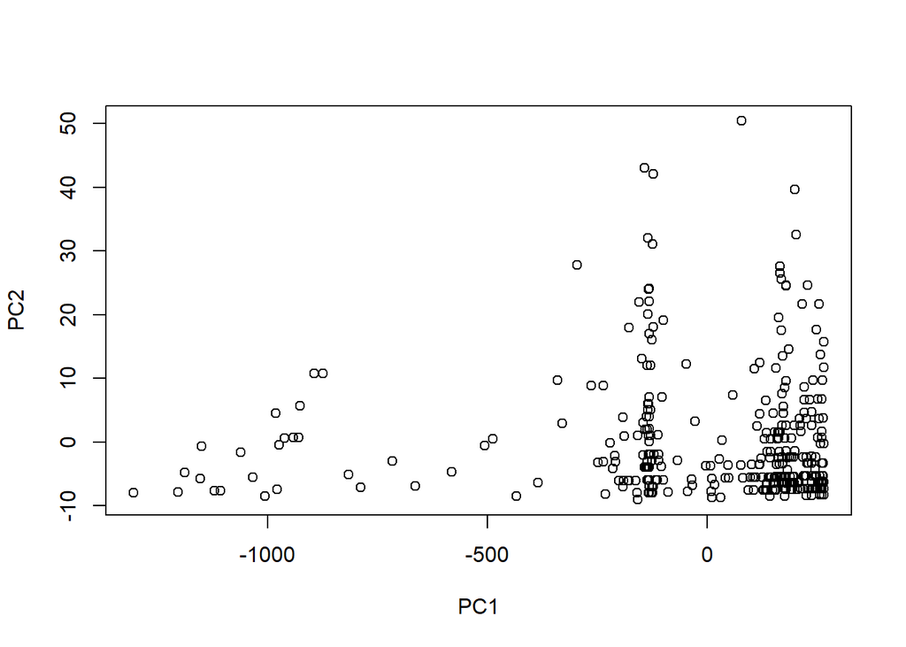

```r
icepca2c <- icepca$x[,1:2]
plot(icepca2c)
```

From the scatter plot, we can clearly see three clusters. Let’s see if KMeans will help us to pick them up.

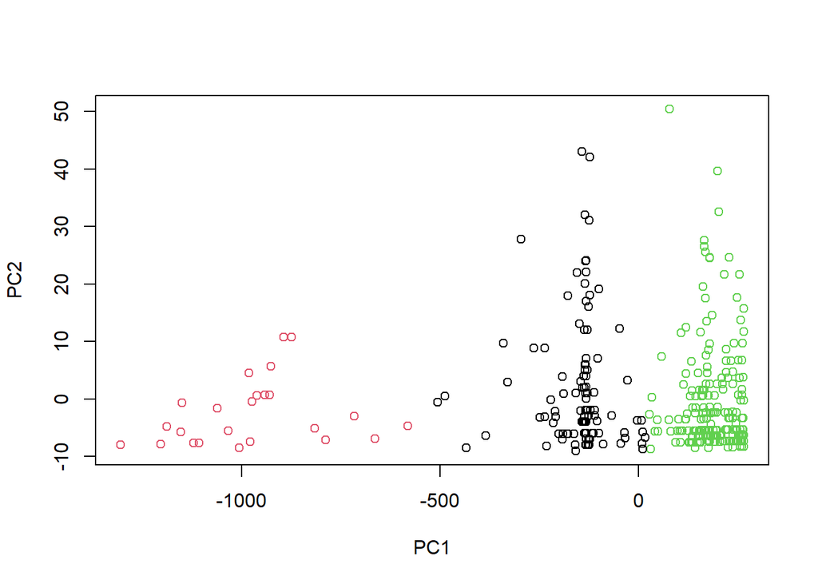

```r
cl <- kmeans(icepca2c, centers = 3)
plot(icepca2c, col = cl$cluster)
```

It looks like the clustering works pretty nicely. So now, it is your turn. Think about two things:

1. What could the two dimensions mean?
2. How would you interpret the KMeans clustering?

One very good tool to facilitate your interpretation is `biplot()`. Read more about biplot here:https://blogs.sas.com/content/iml/2019/11/06/what-are-biplots.html

Or check out this [tutorial](http://strata.uga.edu/8370/lecturenotes/principalComponents.html)by University of Georgia.

Here the PCA result is influenced by the scale of each variable. So you can also try to scale the variables and run PCA again to compare the difference.

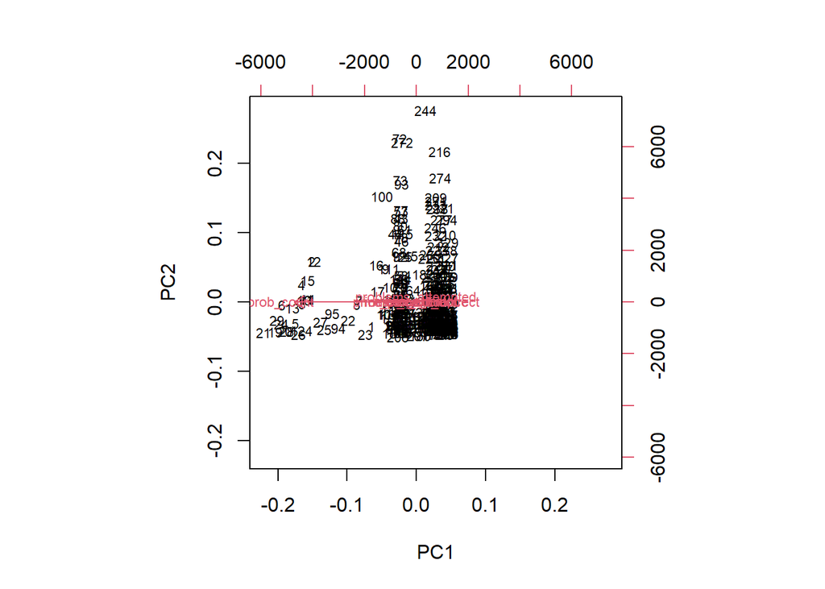

```r
biplot(icepca, cex=.7)
```

## Final Comments

Given any high-dimensional dataset, I suggest starting with PCA in order to visualize the relationship between points and to understand the main variance in the data. Certainly PCA is not useful for every high-dimensional dataset, but it offers a straightforward and efficient path to gaining insight into high-dimensional data.

PCA’s main weakness is that it tends to be highly affected by outliers in the data. For this reason, many robust variants of PCA have been developed, such as `sparsepca`.

In addition, PCA, similar to KMeans, is based on the operationalization of distance. So it does not work very well with categorical variables. Sometimes, you may be able to get away with dichotomous variables (therefore, you can do one-hot encoding) and get good enough results. Theoretically, this may not be the best choice. Other methods such as multiple correspondence analysis but the implementation in Python can be complicated. Feel free to read this article to get more practical tips on PCA and related methods in you want to dig deeper:

Nguyen, L. H., & Holmes, S. (2019). Ten quick tips for effective dimensionality reduction. *PLoS computational biology, 15*(6), 1-19.https://doi.org/10.1371/journal.pcbi.1006907

## Your Tasks for ICE 6

1. follow my tutorial and learn how to implement PCA.
2. think about what are you going to do with this method (e.g., implications and applications).
3. keep good record of your ICEs. Save the `.ipynb` files in a same place. You will need them later.